# Exercise: Fitting all parameters of the SIR model

Aaron A. King and Edward L. Ionides

**R codes for this document**

## Exercise

In all of the foregoing, we have assumed a fixed value of the dispersion parameter $k$, of the negative binomial measurement model. We’ve also fixed one or the other of $\mu_{IR}$, $\eta$. Now attempt to estimate all the parameters simultaneously. How much is the fit improved?

## Solution

### Setup

First, we set up the problem, loading packages, initializing a parallel environment, constructing our SIR model, and identifying the putative MLE. The pomp constructed by the `source` command below is named `measSIR`. We take for our putative MLE the point in our database with the highest measured likelihood.

```r
library(tidyverse)
library(pomp)
library(iterators)
library(doFuture)
plan(multisession)

source("https://kingaa.github.io/serrapilheira/pfilter/model.R")

read_csv("measles_params.csv") |>
  filter(!is.na(loglik), loglik.se<1) |>
  filter(loglik==max(loglik)) |>
  select(-loglik,-loglik.se) -> coef(measSIR)
```

The putative MLE is

| 3.63 |
| --- |
| 2.00 |
| 0.06 |
| 10.00 |
| 0.61 |
| 38000.00 |

### Local search

We’ll begin, as in the Lesson, by performing a local search with only $N$ fixed. The purpose of this is to evaluate the performance of the search algorithm, so that we can tune the algorithm’s parameters.

Windows users, beware! The following triggers a C snippet compilation within a parallel block, which will not succeed on many Windows machines. See this discussion for an explanation of how to circumvent this problem.

```r
foreach(i=1:8,.combine=c,
  .options.future=list(seed=482942941)
) %dofuture% {
  library(tidyverse)
  library(pomp)
  measSIR |>
    mif2(
      Np=2000, Nmif=40,
      cooling.fraction.50=0.5,
      rw.sd=rw_sd(Beta=0.02, rho=0.02, mu_IR=0.02, k=0.02, eta=ivp(0.05)),
      partrans=parameter_trans(log=c("Beta","k","mu_IR"),logit=c("rho","eta")),
      paramnames=c("Beta","rho","k","eta","mu_IR")
    )
} -> mifs_local
```

We examine the traces of the IF2 runs:

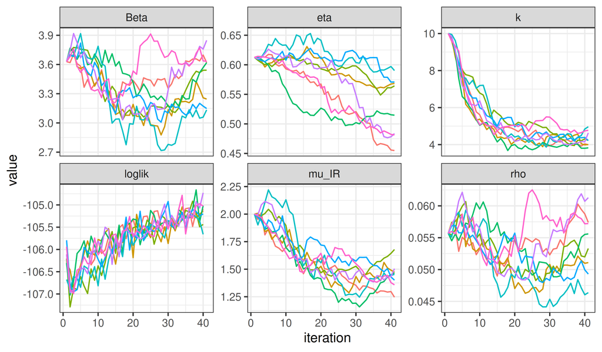

```r
mifs_local |>
  traces() |>
  melt() |>
  filter(name != "N") |>
  ggplot(aes(x=iteration,y=value,group=.L1,color=factor(.L1)))+
  geom_line()+
  guides(color="none")+
  facet_wrap(~name,scales="free_y")
```

We now evaluate the log likelihood at each of the resulting points.

```r
foreach(mf=mifs_local,.combine=rbind,
  .options.future=list(seed=908222057)
  ) %dofuture% {
  library(tidyverse)
  library(pomp)
  evals <- replicate(10, logLik(pfilter(mf,Np=2000)))
  ll <- logmeanexp(evals,se=TRUE)
  mf |> coef() |> bind_rows() |>
    bind_cols(loglik=ll[1],loglik.se=ll[2])
} -> results
```

The above calculations took a total of 17.9 s on 24 cpus. What do they show us?

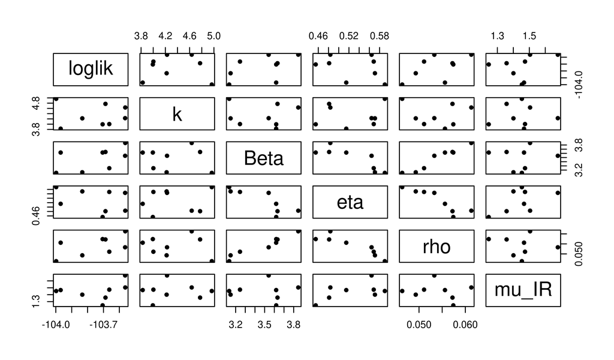

```r
pairs(~loglik+k+Beta+eta+rho+mu_IR,data=results,pch=16)
```

As usual, we store these results in a database.

```r
read_csv("measles_params.csv") |>
  bind_rows(results) |>
  arrange(-loglik) |>
  write_csv("fitall_params.csv")
```

Now we attempt a global search of the $k$-$\beta$-$\rho$-$\eta$-$\mu_{IR}$ space.

We set up a design of starting points. The `freeze` command is described here.

```r
freeze(
  runif_design(
    lower=c(Beta=5,rho=0.2,eta=0,k=1,mu_IR=0.5),
    upper=c(Beta=80,rho=0.9,eta=1,k=30,mu_IR=2),
    nseq=500
  ),
  seed=2062379496
) -> guesses
```

```r
mf1 <- mifs_local[[1]]
fixed_params <- coef(measSIR,c("N"))
```

The following may look somewhat familar.

```r
foreach(guess=iter(guesses,"row"), .combine=rbind,
  .options.future=list(seed=274481374)
) %dofuture% {
  library(tidyverse)
  library(pomp)
  mf1 |>
    mif2(
      Nmif=100,Np=2000,
      params=c(unlist(guess),fixed_params)
    ) |>
    mif2(Nmif=100) |>
    mif2(Nmif=100) -> mf
  replicate(
    10,
    mf |> pfilter(Np=2000) |> logLik()
  ) |>
    logmeanexp(se=TRUE) -> ll
  mf |> coef() |> bind_rows() |>
    bind_cols(loglik=ll[1],loglik.se=ll[2])
} -> results
```

This global search from 500 starts took 490 s on 250 cpus. We append the results to our database and have a look.

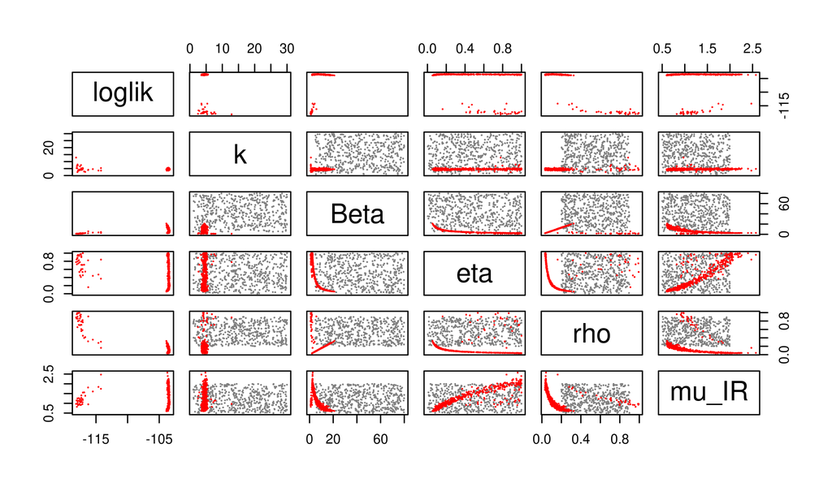

```r
read_csv("fitall_params.csv") |>
  bind_rows(results) |>
  filter(is.finite(loglik)) |>
  arrange(-loglik) |>
  write_csv("fitall_params.csv")

results |>
  filter(is.finite(loglik)) |>
  filter(loglik>max(loglik)-50) |>
  bind_rows(guesses) |>
  mutate(type=if_else(is.na(loglik),"guess","result")) |>
  arrange(type) -> all

pairs(~loglik+k+Beta+eta+rho+mu_IR, data=all, pch=16, cex=0.3,
      col=ifelse(all$type=="guess",grey(0.5),"red"))
```

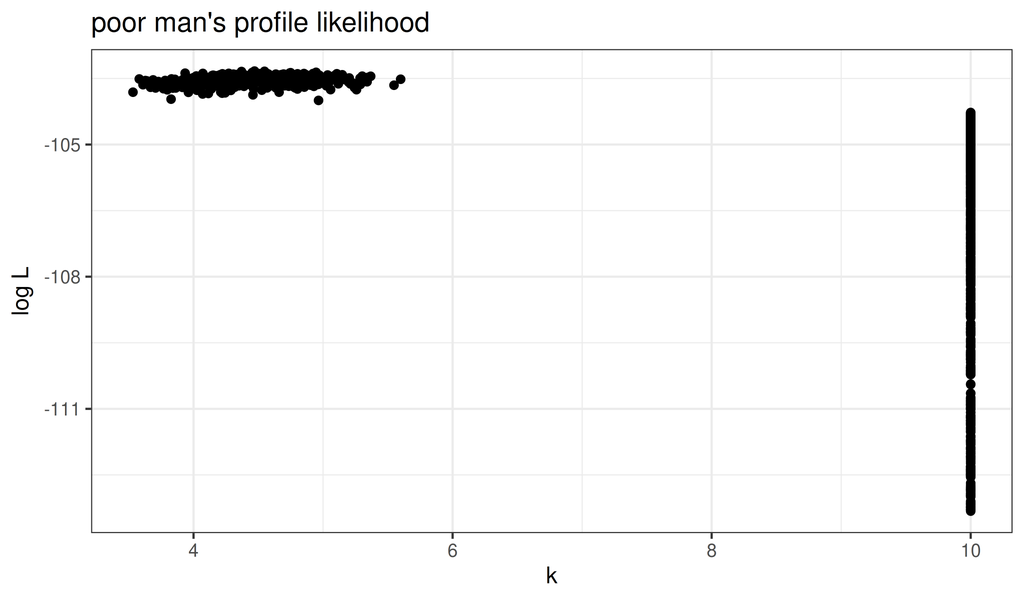

```r
read_csv("fitall_params.csv") |>
  filter(loglik>max(loglik)-50) -> all

all |>
  filter(loglik>max(loglik)-10) |>
  ggplot(aes(x=k,y=loglik))+
  geom_point()+
  labs(
    x=expression(k),
    y=expression(log~L),
    title="poor man's profile likelihood"
  )
```

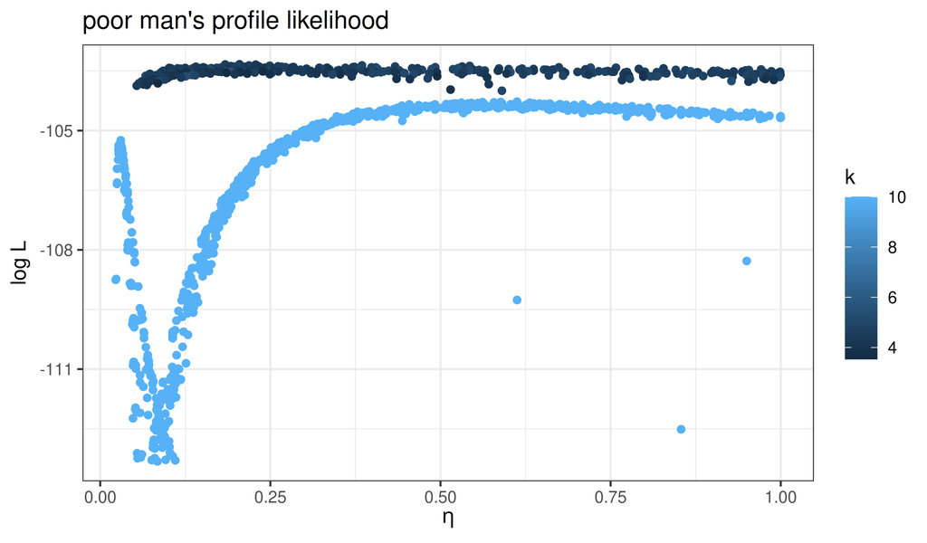

```r
all |>
  filter(loglik>max(loglik)-10) |>
  ggplot(aes(x=eta,y=loglik,color=k))+
  geom_point()+
  labs(
    x=expression(eta),
    y=expression(log~L),
    title="poor man's profile likelihood"
  )
```

It does appear that our global search has improved the likelihood, at least in part by reducing $k$. That is, by *increasing* the measurement error.

Perhaps unsurprisingly, these poor-man’s profiles suggest there is a very flat ridge in the surface. We can see some of the tradeoffs involved with a scatterplot matrix. In the following, the results of our earlier fitting (where $k=10$) are in blue; the new results are in red.

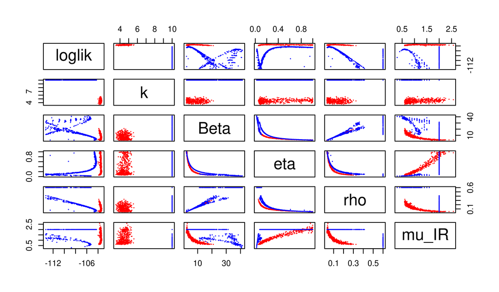

```r
pairs(~loglik+k+Beta+eta+rho+mu_IR, pch=16, cex=0.3,
  data=filter(all,loglik>max(loglik)-10),
  col=ifelse(round(all$k,2)==10,"blue","red"))
```

### A profile calculation

Because this ridge appears flat in the $\eta$-direction, we will profile over $\eta$ to improve our estimates. The following sets up a design of guesses, to be used as starting points for the profile computation.

```r
read_csv("fitall_params.csv") |>
  filter(loglik>max(loglik)-10,loglik.se<1) |>
  sapply(range) -> box

freeze(
  profile_design(
    eta=seq(0.01,0.99,length=40),
    lower=box[1,c("Beta","rho","k","mu_IR")],
    upper=box[2,c("Beta","rho","k","mu_IR")],
    nprof=25, type="runif"
  ),
  seed=1893696051
)-> guesses
```

```r
foreach(guess=iter(guesses,"row"), .combine=rbind,
  .options.future=list(seed=830007657)
) %dofuture% {
  library(tidyverse)
  library(pomp)
  mf1 |>
    mif2(
      Nmif=100,Np=2000,
      params=c(unlist(guess),fixed_params),
      rw.sd=rw_sd(Beta=0.02, rho=0.02, mu_IR=0.02, k=0.02),
      partrans=parameter_trans(log=c("Beta","mu_IR","k"),logit="rho"),
      paramnames=c("Beta","mu_IR","k","rho")
    ) |>
    mif2(Nmif=100,cooling.fraction.50=0.3) -> mf
  replicate(
    10,
    mf |> pfilter(Np=2000) |> logLik()
  ) |> logmeanexp(se=TRUE) -> ll
  mf |> coef() |> bind_rows() |>
    bind_cols(loglik=ll[1],loglik.se=ll[2])
} -> results
```

This profile calculation used about $110$ cpu s per start.

We now examine the profile traces. Note that we include a trace of the basic reproductive number, $R_0$.

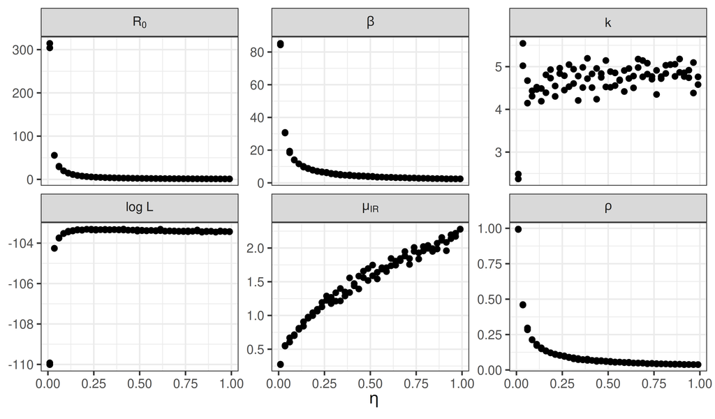

```r
results |>
  filter(
    is.finite(loglik),
    loglik.se<1
  ) |>
  group_by(eta) |>
  filter(rank(-loglik)<=2) |>
  ungroup() |>
  reframe(
    eta=eta,
    `log~L`=loglik,
    `R[0]`=Beta/mu_IR,
    beta=Beta,
    `mu[IR]`=mu_IR,
    k=k,
    rho=rho
  ) |>
  pivot_longer(-`eta`) |>
  ggplot(aes(x=`eta`,y=value))+
  geom_point()+
  labs(y=NULL,x=expression(eta))+
  facet_wrap(~name,scales="free_y",labeller=label_parsed)
```

### Conclusions

Releasing all constraints on the parameters results in only a small improvement in the log likelihood. Indeed, by AIC, the improvement is not judged to be worthwhile. Nevertheless, removing the constraints allows us to evaluate whether our assumptions about known values of certain parameters play a role in the conclusions. In the event, they were not playing much of a role.

Let us return to the central question: How does the model account for the data?

Clearly, the model can account for the data equally well for all but the smallest values of $\eta$. That is, unless the fraction of susceptibles in the population was too small to allow for an outbreak of the observed size, one can obtain an outbreak that looks like the observed one from an SIR model in a population of sufficient size. This interpretation is confirmed by the fact that, as one decreases $\eta$, one has to increase the reporting efficiency $\rho$ to explain the data.

Now, across the confidence interval for $\eta$, say $(0.03, 1)$, it is clear from the profile trace plots above, that the model needs both $\beta$ and $\rho$ to be relatively low and the infectious period to be relatively short (though average infectious periods of as long as $1.7$ wk are within the confidence interval).

Top of this document  
Previous page  
Back to the lesson  
Course homepage  
Acknowledgments

Licensed under the [Creative Commons Attribution-NonCommercial license](http://creativecommons.org/licenses/by-nc/4.0/). Please share and remix noncommercially, mentioning its origin.